# Lesson 5

### Multivariate Data

Notes:

```r
library(ggplot2)
library(dplyr)
```

### Moira Perceived Audience Size Colored by Age

Notes: 有时候分析方向会出错 ***

### Third Qualitative Variable

Notes:

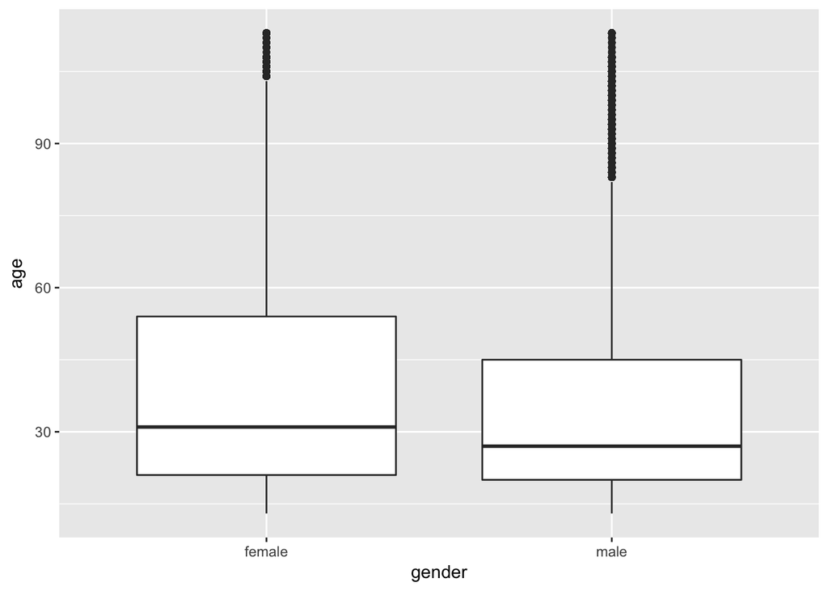

```r
pf <- read.csv("../lesson3/pseudo_facebook.tsv", sep="\t")
ggplot(aes(x = gender, y = age),data = subset(pf, !is.na(gender))) + geom_boxplot()
```

### Plotting Conditional Summaries

Notes:

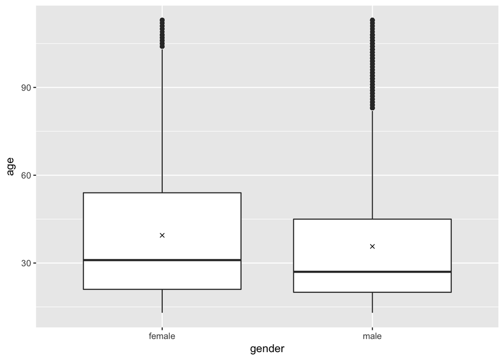

```r
ggplot(aes(x=gender, y=age), data=subset(pf, !is.na(gender))) +
  geom_boxplot() +
  stat_summary(fun.y=mean, geom="point", shape=4)
```

```r
pf.fc_by_age_gender <- pf %>%
    filter(!is.na(gender)) %>%
    group_by(age, gender) %>%
    summarise(mean_friend_count=mean(friend_count), median_friend_count=median(friend_count), n=n())
head(pf.fc_by_age_gender)
```

```
## # A tibble: 6 x 5
## # Groups:   age [3]
##     age gender mean_friend_count median_friend_count     n
##   <int> <fctr>             <dbl>               <dbl> <int>
## 1    13 female          259.1606               148.0   193
## 2    13   male          102.1340                55.0   291
## 3    14 female          362.4286               224.0   847
## 4    14   male          164.1456                92.5  1078
## 5    15 female          538.6813               276.0  1139
## 6    15   male          200.6658               106.5  1478
```

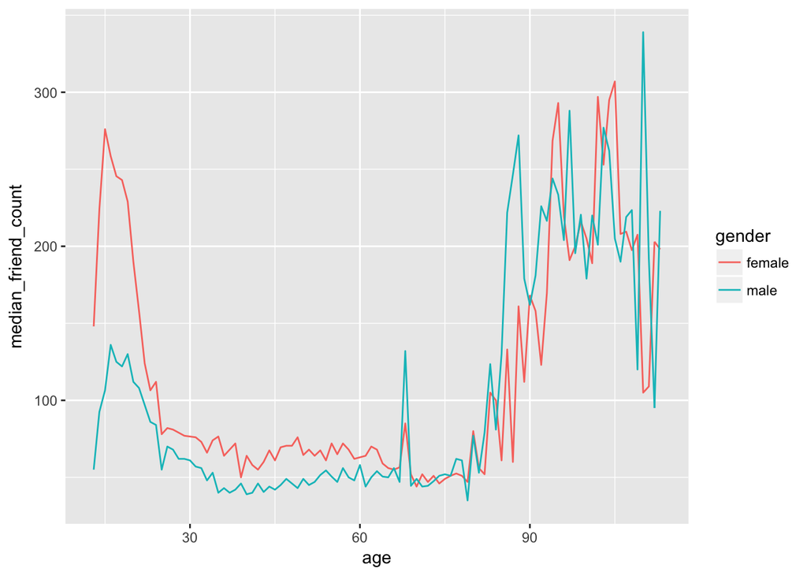

```r
ggplot(aes(x=age, y=median_friend_count), data=subset(pf.fc_by_age_gender, !is.na(gender))) + geom_line(aes(color=gender))
```

### Thinking in Ratios Notes:中位数中，男性用户的数量比女性用户少，至少在60岁之前。在之后的数据波动较大

### Wide and Long Format

Notes:

### Reshaping Data

Notes:

```r
library(reshape2)
pf.fc_by_age_gender.wide <- dcast(pf.fc_by_age_gender, age~gender, value.var = "median_friend_count")
```

### Ratio Plot

Notes:

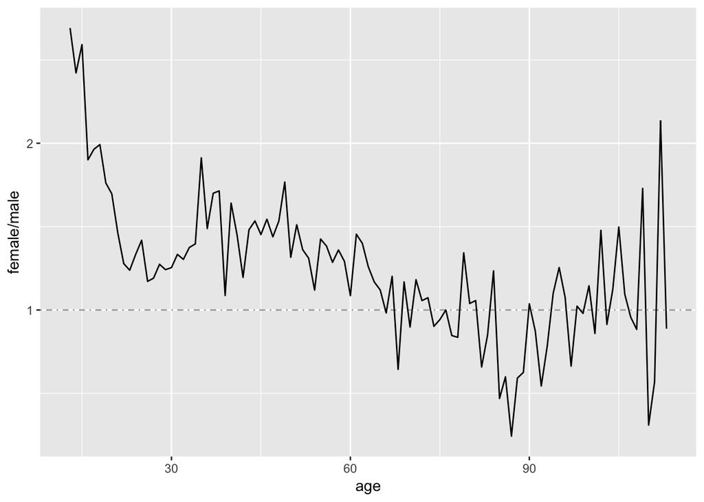

```r
ggplot(aes(x=age, y=female/male), data=pf.fc_by_age_gender.wide) +
  geom_line() +
  geom_hline(yintercept=1, alpha=.4, linetype=4)
```

### Third Quantitative Variable

Notes: 可以使用with方法， pf$year_joined<-with(pf, floor(2014-tenure/365))

```r
pf$year_joined <- floor(2014 -pf$tenure/365)
```

### Cut a Variable

Notes: [cut方法](https://www.r-bloggers.com/r-function-of-the-day-cut-2/)

```r
pf$year_joined.bucket <- cut(pf$year_joined, breaks=c(2004, 2009, 2011, 2012, 2014))
```

### Plotting it All Together

Notes:证实了一点，因为加入时间的不同，对朋友数量还是有差异的

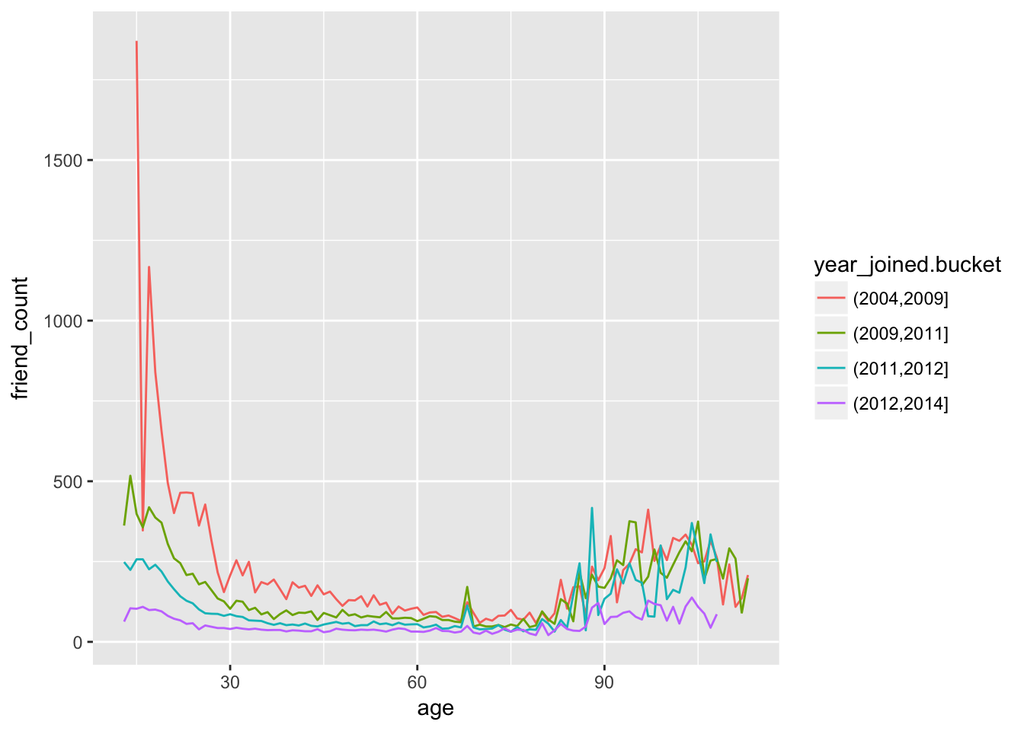

```r
ggplot(aes(x=age, y=friend_count), data=subset(pf, !is.na(year_joined.bucket))) +
  geom_line(aes(color=year_joined.bucket), stat="summary", fun.y=median)
```

### Plot the Grand Mean

Notes: 更加强体现了使用时长对用户数量的影响

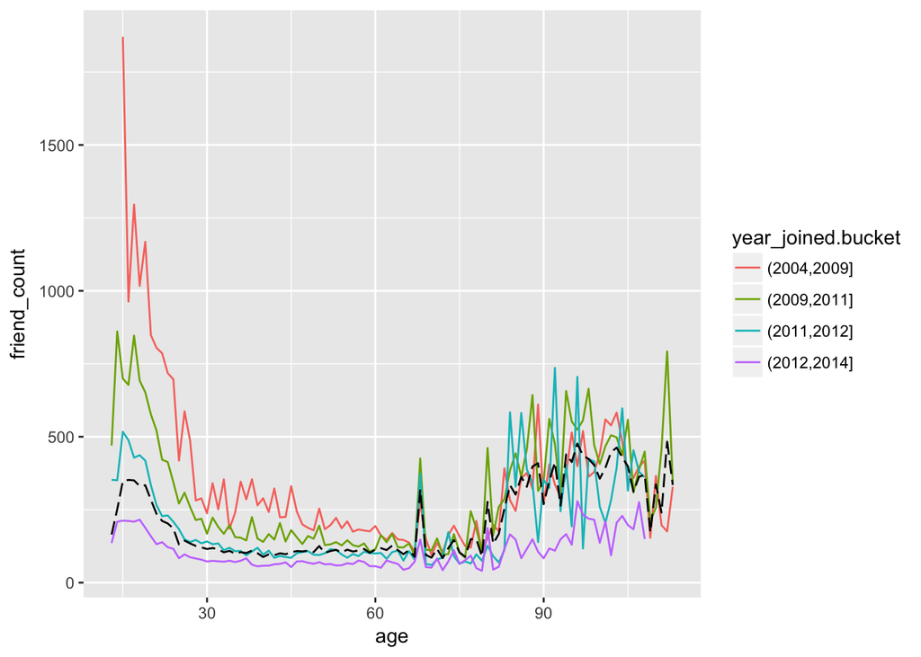

```r
ggplot(aes(x=age, y=friend_count), data=subset(pf, !is.na(year_joined.bucket))) +
geom_line(aes(color=year_joined.bucket), stat="summary", fun.y=mean, linetype=1) +
geom_line(stat="summary", fun.y=mean, linetype=5)
```

### Friending Rate

Notes:从最大值中显示每天有加入朋友数量为417人，存在异常值

```r
with(subset(pf, tenure>=1), summary(friend_count/tenure))
```

```
##     Min.  1st Qu.   Median     Mean  3rd Qu.     Max.
##   0.0000   0.0775   0.2205   0.6096   0.5658 417.0000
```

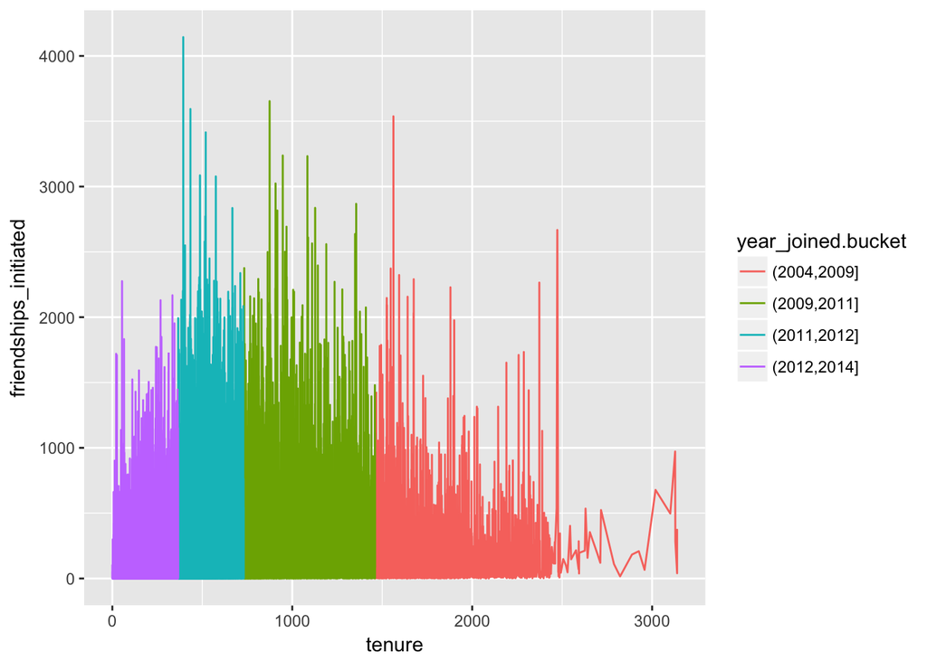

```r
ggplot(aes(x=tenure, y=friendships_initiated), data=subset(pf, !is.na(year_joined.bucket))) +
 geom_line(aes(color=year_joined.bucket))
```

***

### Friendships Initiated

Notes:

What is the median friend rate? 0.2205 What is the maximum friend rate? 417

```r
with(subset(pf, tenure>=1), summary(friend_count/tenure))
```

```
##     Min.  1st Qu.   Median     Mean  3rd Qu.     Max.
##   0.0000   0.0775   0.2205   0.6096   0.5658 417.0000
```

### Bias-Variance Tradeoff Revisited

Notes: 使用不同的时间在调整x轴的变化，减少噪音

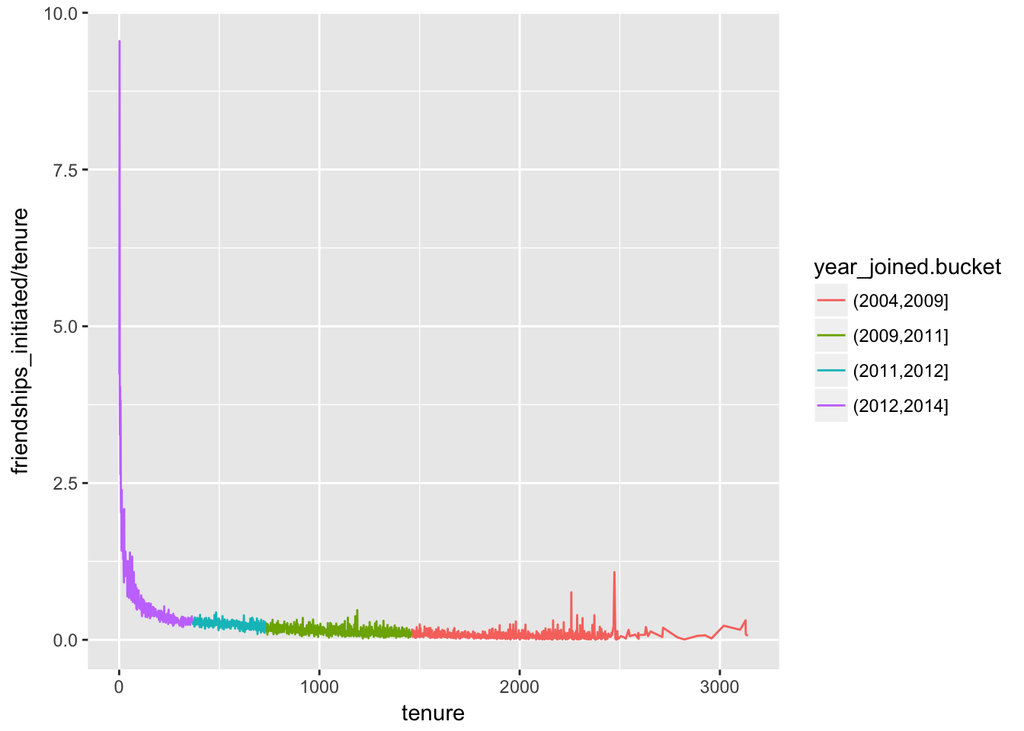

```r
ggplot(aes(x = tenure, y = friendships_initiated / tenure),
       data = subset(pf, tenure >= 1)) +
  geom_line(aes(color = year_joined.bucket),
            stat = 'summary',
            fun.y = mean)
```

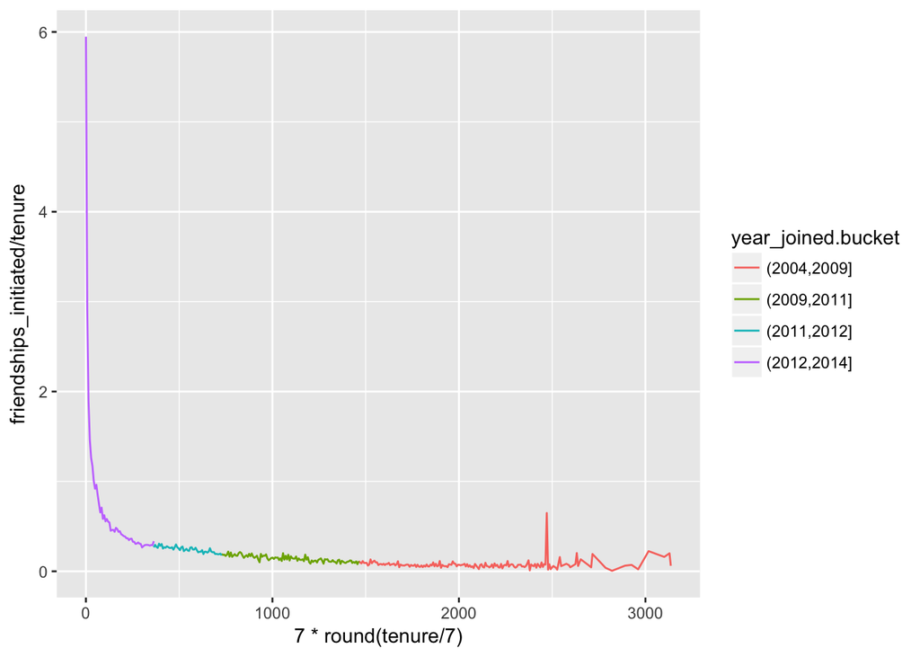

```r
ggplot(aes(x = 7 * round(tenure / 7), y = friendships_initiated / tenure),
       data = subset(pf, tenure > 0)) +
  geom_line(aes(color = year_joined.bucket),
            stat = "summary",
            fun.y = mean)
```

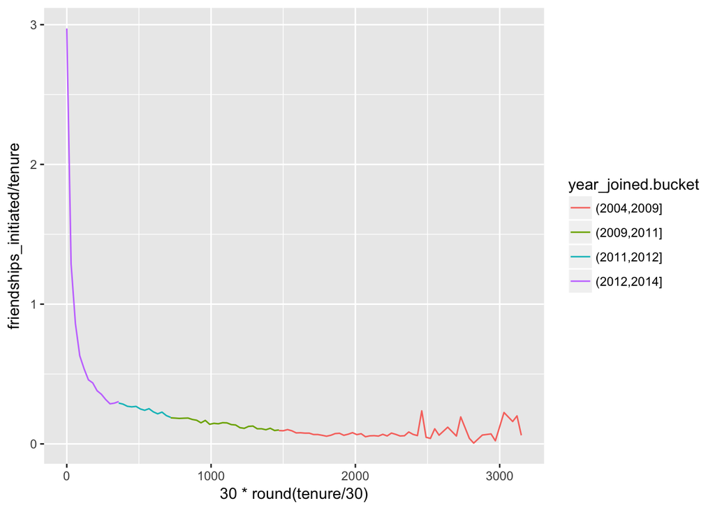

```r
ggplot(aes(x = 30 * round(tenure / 30), y = friendships_initiated / tenure),
       data = subset(pf, tenure > 0)) +
  geom_line(aes(color = year_joined.bucket),
            stat = "summary",
            fun.y = mean)
```

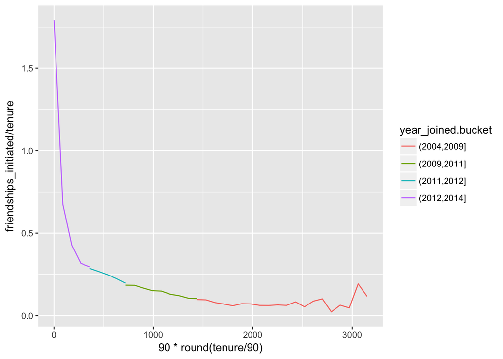

```r
ggplot(aes(x = 90 * round(tenure / 90), y = friendships_initiated / tenure),
       data = subset(pf, tenure > 0)) +
  geom_line(aes(color = year_joined.bucket),
            stat = "summary",
            fun.y = mean)
```

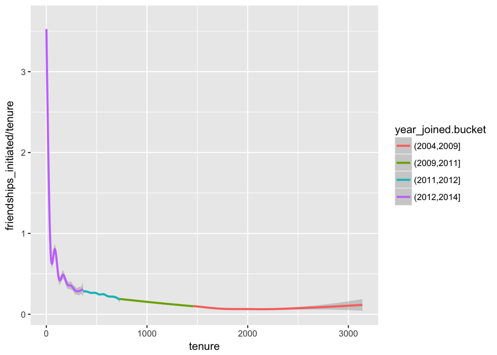

```r
ggplot(aes(x=tenure, y=friendships_initiated/tenure), data=subset(pf, tenure>=1)) +
  geom_smooth(aes(color=year_joined.bucket))
```

***

### Sean’s NFL Fan Sentiment Study

Notes:

### Introducing the Yogurt Data Set

Notes:

### Histograms Revisited

Notes:

```r
yo = read.csv("yogurt.csv")
yo$id <- factor(yo$id)
```

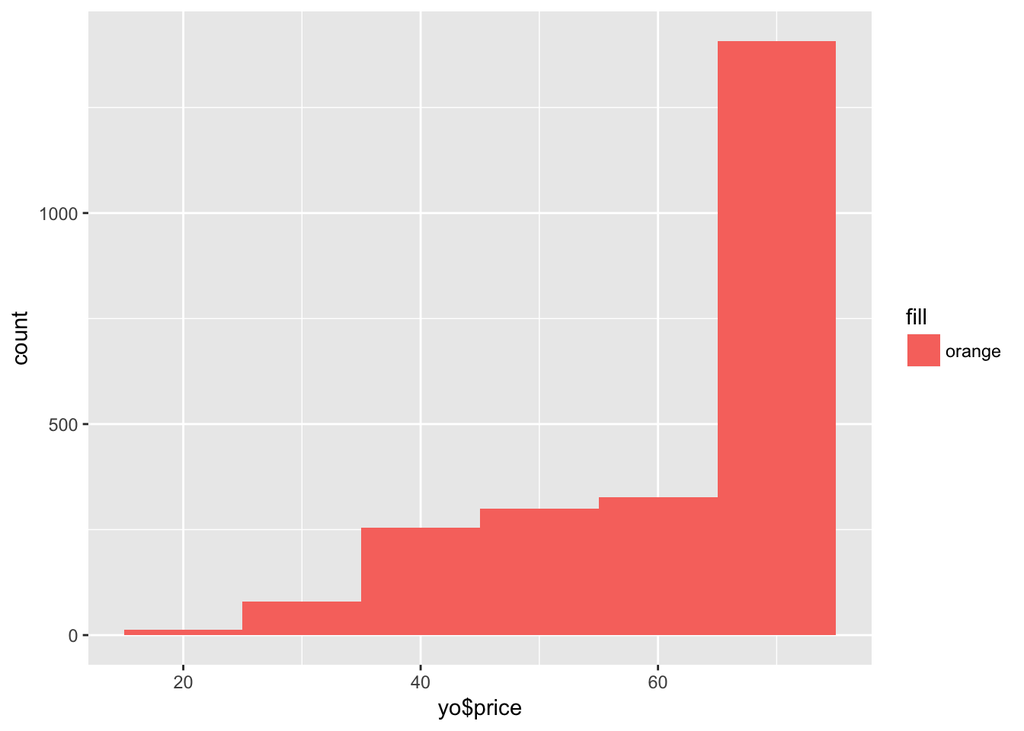

```r
qplot(yo$price, binwidth=10, fill="orange")
```

### Number of Purchases

Notes: tranform是直接在源数据集上变更，不需要哦在另外定义列名称

```r
yo <-transform(yo, all.purchase=strawberry+blueberry+pina.colada+plain+mixed.berry)
```

### Prices over Time

Notes:随着时间推移，用户购买高价的人数增多，在后期还有低价购买的人可能是使用了优惠券

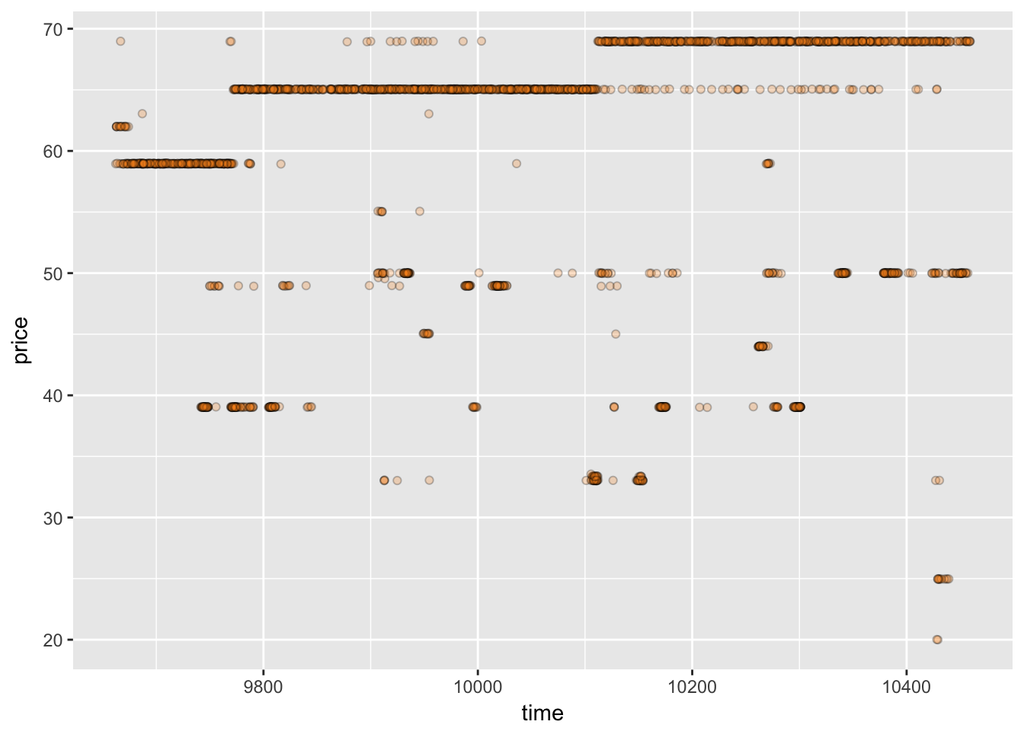

```r
ggplot(aes(x=time, y=price), data=yo) +
  geom_jitter(shape=21, alpha=.25, fill=I("#F79420"))
```

### Sampling Observations

Notes:因为是需要对小样本进行分析，建立家庭结构和购买之间关系，所以通过抽样来分析

### Looking at Samples of Households

更能发现是否购买变化，针对某个家庭。因为该数据中有针对单个家庭的时间序列变化

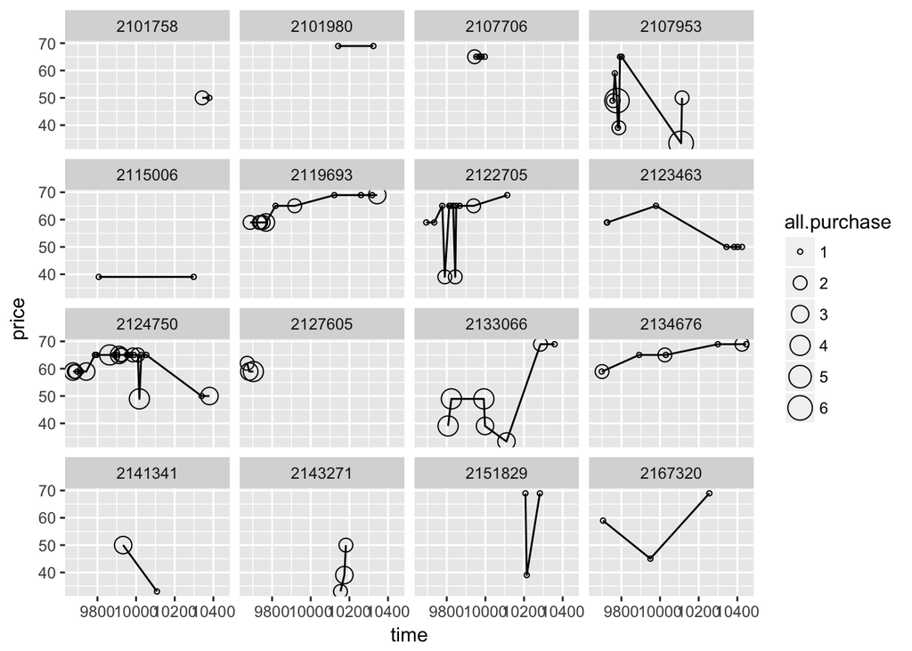

```r
set.seed(4230)
sample.ids <- sample(levels(yo$id), 16)

ggplot(aes(x=time, y=price), data=subset(yo, id %in% sample.ids)) +
  geom_line() +
  geom_point(aes(size=all.purchase), pch=1) +
  facet_wrap(~id)
```

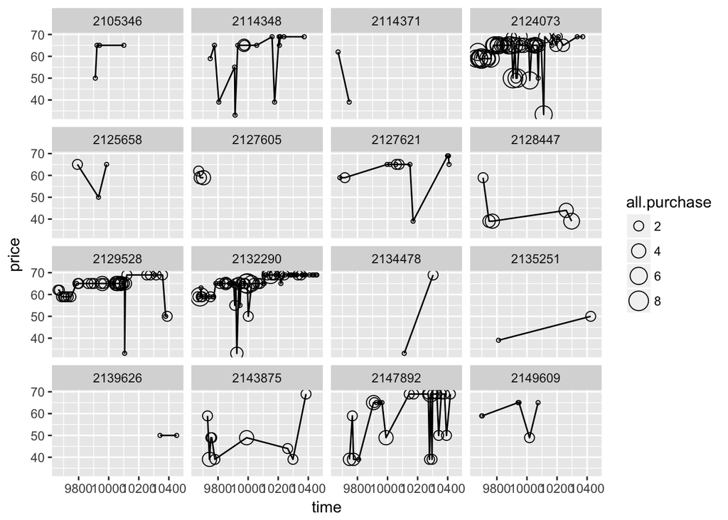

```r
set.seed(1354)
sample.ids <- sample(levels(yo$id), 16)

ggplot(aes(x=time, y=price), data=subset(yo, id %in% sample.ids)) +
  geom_line() +
  geom_point(aes(size=all.purchase), pch=1) +
  facet_wrap(~id)
```

### The Limits of Cross Sectional Data

Notes: 缺少对单个人的数据变化 ***

### Many Variables

Notes: 可以从多个变量是否具有特定关系出发，从不同变量来验证分析；同样可能是需要从大量数据集中取分析小数据集 ***

### Scatterplot Matrix

Notes: 可以使用GGally的package来对整体的变量进行分析 ***

### Even More Variables

Notes: 设置样本种子，体现数据一致性。取消了id，加入年份以及后续加的变量 ***

```r
library(GGally)
theme_set(theme_minimal(20))

set.seed(1836)
pf_subset <- pf[, c(2:15)]
names(pf_subset)
```

```
##  [1] "age"                   "dob_day"
##  [3] "dob_year"              "dob_month"
##  [5] "gender"                "tenure"
##  [7] "friend_count"          "friendships_initiated"
##  [9] "likes"                 "likes_received"
## [11] "mobile_likes"          "mobile_likes_received"
## [13] "www_likes"             "www_likes_received"
```

[figure not shown]

```r
ggpairs(pf_subset[sample.int(nrow(pf_subset), 1000), ])
```

### Heat Maps

Notes:

```r
nci <- read.table("nci.tsv")
colnames(nci) <- c(1:64)
```

```r
library(reshape)
nci.long.samp <- melt(as.matrix(nci[1:200,]))
names(nci.long.samp) <- c("gene", "case", "value")
head(nci.long.samp)
```

```
##   gene case  value
## 1    1    1  0.300
## 2    2    1  1.180
## 3    3    1  0.550
## 4    4    1  1.140
## 5    5    1 -0.265
## 6    6    1 -0.070
```

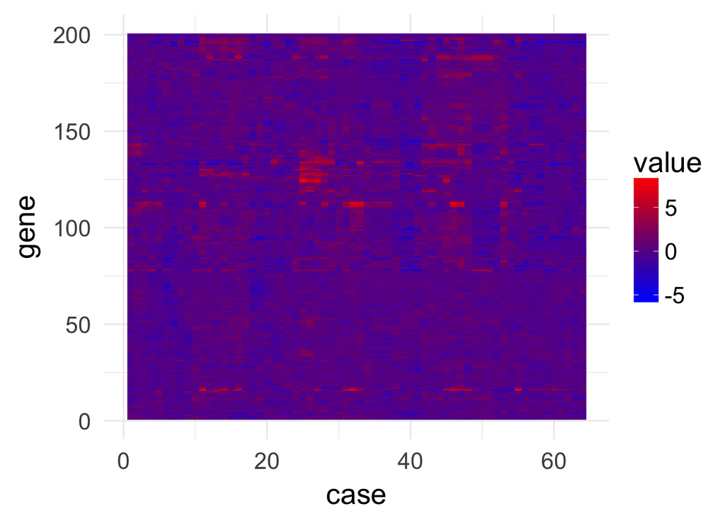

```r
ggplot(aes(y = gene, x = case, fill = value),
  data = nci.long.samp) +
  geom_tile() +
  scale_fill_gradientn(colours = colorRampPalette(c("blue", "red"))(100))
```

### Analyzing Three of More Variables

Reflection: 多变量分析，多组／散点图，热力图，长短数据集变化 ***

Click **KnitHTML** to see all of your hard work and to have an html page of this lesson, your answers, and your notes!